# DATOS DE SELECCIONES Y JUGADORES - MUNDIAL QATAR 2022.

14 Noviembre 2022.

## EXTRACCIÓN DE DATOS, FUENTE Y SOFTWARE.

Los datos fueron extraídos mediante webscraping de la página web https://www.transfermarkt.es/.

Para la extracción de datos, limpieza, procesamiento y presentación se usó el software R.

La documentación y los códigos de programación los puede encontrar en mi github: https://github.com/CesarAHN/datos-selecciones-jugadores-qatar-2022

## JUGADORES POR POSICIONES

**Japón y Camerún han convocado a más delanteros.**

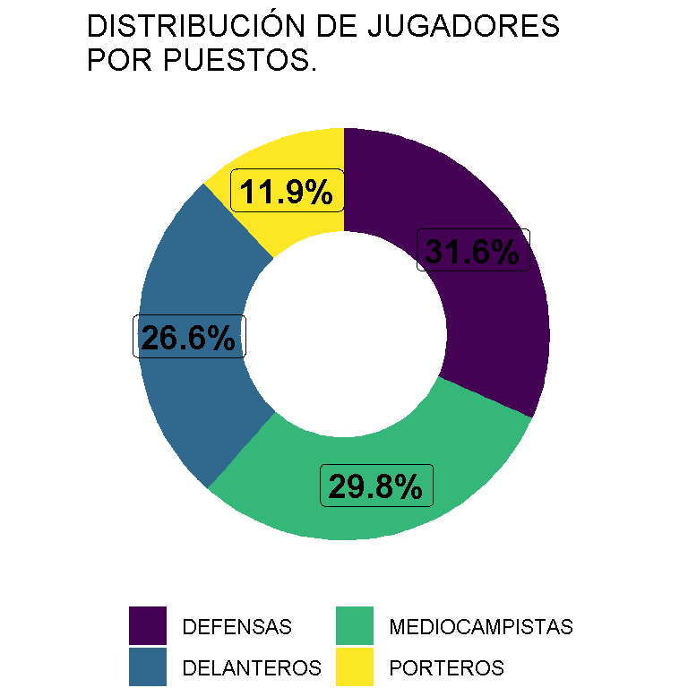

SELECCIONES QUE LLEVAN MÁS JUGADORES POR PUESTO.

| PUESTO | N | PAIS | JUGADORES | % |
| --- | --- | --- | --- | --- |
| DEFENSAS |  | IRAN | 9 | 36.00% |
| DEFENSAS |  | EEUU | 9 | 34.62% |
| DEFENSAS |  | INGLATERRA | 9 | 34.62% |
| DEFENSAS |  | CROACIA | 9 | 34.62% |
| DEFENSAS |  | ALEMANIA | 9 | 34.62% |
| DEFENSAS |  | ARGENTINA | 9 | 34.62% |
| DEFENSAS |  | KOREA DEL SUR | 9 | 34.62% |
| DEFENSAS |  | URUGUAY | 9 | 34.62% |
| DEFENSAS |  | TUNEZ | 9 | 34.62% |
| DEFENSAS |  | AUSTRALIA | 9 | 34.62% |
| DEFENSAS |  | ECUADOR | 9 | 34.62% |
| DEFENSAS |  | ARABIA SAUDI | 9 | 34.62% |
| DEFENSAS |  | GHANA | 9 | 34.62% |
| DEFENSAS |  | FRANCIA | 9 | 34.62% |
| DEFENSAS |  | GALES | 9 | 34.62% |
| DELANTEROS |  | JAPON | 10 | 38.46% |
| DELANTEROS |  | CAMERUN | 10 | 38.46% |
| MEDIOCAMPISTAS |  | PORTUGAL | 11 | 42.31% |
| PORTEROS |  | IRAN | 4 | 16.00% |
| PORTEROS |  | SUIZA | 4 | 15.38% |
| PORTEROS |  | TUNEZ | 4 | 15.38% |

## JUGADORES POR DOMINIO DE PIE

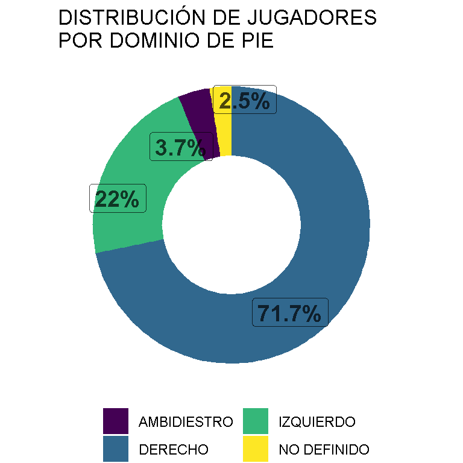

TOP 4 DE SELECCIONES QUE LLEVAN MÁS JUGADORES CON DOMINIO DE PIE IZQUIERDO.

| N | PAIS | JUGADORES | % |
| --- | --- | --- | --- |
|  | SERBIA | 9 | 34.62% |
|  | COSTA RICA | 9 | 34.62% |
|  | BRASIL | 8 | 30.77% |
|  | ARABIA SAUDI | 8 | 30.77% |

ELABORACIÓN: https://github.com/CesarAHN  
FUENTE: TRANSFERMARKT

## ALTURA PROMEDIO POR SELECCIONES

**Las 5 primeras selecciones con la mayor altura promedio son de Europa.** **Argentina y México se ubican en el top 5 de selecciones con la altura promedio más baja.**

TOP 5 DE SELECCIONES CON LA TALLA PROMEDIO MÁS ALTA.

| N | PAIS | TALLA PROMEDIO |
| --- | --- | --- |
|  | SERBIA | 1.87 m |
|  | FRANCIA | 1.86 m |
|  | DINAMARCA | 1.86 m |
|  | ALEMANIA | 1.85 m |
|  | BELGICA | 1.85 m |

ELABORACIÓN: https://github.com/CesarAHN  
FUENTE: TRANSFERMARKT

TOP 5 DE SELECCIONES CON LA TALLA PROMEDIO MÁS BAJA.

| N | PAIS | TALLA PROMEDIO |
| --- | --- | --- |
|  | ARABIA SAUDI | 1.79 m |
|  | MEXICO | 1.79 m |
|  | ARGENTINA | 1.79 m |
|  | GHANA | 1.79 m |
|  | QATAR | 1.8 m |

ELABORACIÓN: https://github.com/CesarAHN  
FUENTE: TRANSFERMARKT

## TOP JUGADORES ALTOS Y BAJOS

**Andries Noppert de paises bajos con 2.03 metros es el jugador más alto del mundial. Mientras que el más bajo es Tariq Lamptey de Ghana con 1.63 metros.**

TOP 4 DE JUGADORES MÁS ALTOS.

En metros.

| N | PAIS | JUGADOR | PUESTO | TALLA |
| --- | --- | --- | --- | --- |
|  | PAISES BAJOS | ANDRIES NOPPERT | PORTEROS | 2.03 m |
|  | SERBIA | VANJA MILINKOVIĆ-SAVIĆ | PORTEROS | 2.02 m |
|  | BELGICA | THIBAUT COURTOIS | PORTEROS | 2 m |
|  | AUSTRALIA | HARRY SOUTTAR | DEFENSAS | 1.98 m |

ELABORACIÓN: https://github.com/CesarAHN  
FUENTE: TRANSFERMARKT

TOP 4 DE JUGADORES MÁS BAJOS.

En metros.

| N | PAIS | JUGADOR | PUESTO | TALLA |
| --- | --- | --- | --- | --- |
|  | GHANA | TARIQ LAMPTEY | DEFENSAS | 1.63 m |
|  | CAMERUN | COLLINS FAI | DEFENSAS | 1.65 m |
|  | JAPON | YUKI SOMA | DELANTEROS | 1.66 m |
|  | URUGUAY | LUCAS TORREIRA | MEDIOCAMPISTAS | 1.66 m |

ELABORACIÓN: https://github.com/CesarAHN  
FUENTE: TRANSFERMARKT

## PARTIDOS JUGADOS PROMEDIO

**Qatar es la selección con más partidos jugados en promedio (53), es decir, sus seleccionados tienen la mayor experiencia jugando por su selección.**

TOP 5 DE SELECCIONES CON MÁS PARTIDOS PROMEDIOS JUGADOS.

Media de los partidos jugados por sus seleccionados.

| N | PAIS | MEDIA PARTIDOS |
| --- | --- | --- |
|  | QATAR | 53 |
|  | BELGICA | 52 |
|  | MEXICO | 52 |
|  | URUGUAY | 46 |
|  | COSTA RICA | 44 |

ELABORACIÓN: https://github.com/CesarAHN  
FUENTE: TRANSFERMARKT

TOP 5 DE SELECCIONES CON MENOS PARTIDOS PROMEDIOS JUGADOS.

Media de los partidos jugados por sus seleccionados.

| N | PAIS | MEDIA PARTIDOS |
| --- | --- | --- |
|  | GHANA | 18 |
|  | MARRUECOS | 21 |
|  | AUSTRALIA | 21 |
|  | SENEGAL | 22 |
|  | ECUADOR | 24 |

ELABORACIÓN: https://github.com/CesarAHN  
FUENTE: TRANSFERMARKT

Se calcula como la media de los partidos oficiales jugados por todos los seleccionados convocados.

## MÁS PARTIDOS JUGADOS

TOP 5 DE JUGADORES CON MÁS PARTIDOS OFICIALES JUGADOS CON SU SELECCIÓN.

| N | JUGADOR | PAIS | PARTIDOS JUGADOS |
| --- | --- | --- | --- |
|  | CRISTIANO RONALDO | PORTUGAL | 191 |
|  | ANDRES GUARDADO | MEXICO | 180 |
|  | LIONEL MESSI | ARGENTINA | 165 |
|  | HASAN AL-HAYDOS | QATAR | 160 |
|  | DIEGO GODIN | URUGUAY | 159 |

ELABORACIÓN: https://github.com/CesarAHN  
FUENTE: TRANSFERMARKT

Para esta edición del mundial, 23 jugadores debutarán con su selecciones.

Las selecciones con más debutantes son: Ghana, Paises Bajos y Portugal que han convocado a 3 jugadores que nunca han jugado un partido oficial.

## MÁS GOLES ANOTADOS

**Cristiano Ronaldo, aproximadamente, anota 61 goles cada 100 partidos con su selección, mientras que Messi marca 55 goles cada 100 partidos.**

Para esta edición del mundial, 334 jugadores nunca han marcado un gol con su selección nacional.

Las selecciones con más jugadores que aún no marcan goles con sus selecciones son: Ghana (18), Camerún (17) y Senegal (17).

TOP 6 DE JUGADORES CON MÁS GOLES ANOTADOS CON SU SELECCIÓN.

| N | PAIS | JUGADOR | GOLES | % |
| --- | --- | --- | --- | --- |
|  | PORTUGAL | CRISTIANO RONALDO | 117 | 61.26% |
|  | ARGENTINA | LIONEL MESSI | 91 | 55.15% |
|  | POLONIA | ROBERT LEWANDOWSKI | 76 | 56.72% |
|  | BRASIL | NEYMAR | 75 | 61.98% |
|  | BELGICA | ROMELU LUKAKU | 68 | 66.67% |
|  | URUGUAY | LUIS SUAREZ | 68 | 50.75% |

ELABORACIÓN: https://github.com/CesarAHN  
FUENTE: TRANSFERMARKT

El % se calcula como el cociente entre el número de goles y el número de partidos jugados con su selección.

## EDAD PROMEDIO SELECCIONES

**La selección con la edad promedio más alta es Irán, es 4.2 años superior al promedio de Ghana.**

TOP 5 DE SELECCIONES CON LA MAYOR EDAD PROMEDIO.

| N | PAIS | EDAD PROMEDIO |
| --- | --- | --- |
|  | IRAN | 28.9 |
|  | MEXICO | 28.5 |
|  | ARGENTINA | 27.9 |
|  | BRASIL | 27.9 |
|  | KOREA DEL SUR | 27.8 |

ELABORACIÓN: https://github.com/CesarAHN  
FUENTE: TRANSFERMARKT

TOP 5 DE SELECCIONES CON LA MENOR EDAD PROMEDIO.

| N | PAIS | EDAD PROMEDIO |
| --- | --- | --- |
|  | GHANA | 24.7 |
|  | EEUU | 25.2 |
|  | ECUADOR | 25.6 |
|  | ESPAÑA | 25.6 |
|  | MARRUECOS | 26.2 |

ELABORACIÓN: https://github.com/CesarAHN  
FUENTE: TRANSFERMARKT

## EDAD DE JUGADORES

**En el top 20 de jugadores con mayor edad, México es la selección con más jugadores, 3 en total.**

TOP 6 JUGADORES CON LA MAYOR EDAD.

| N | PAIS | JUGADOR | EDAD | DEBUT |
| --- | --- | --- | --- | --- |
|  | MEXICO | ALFREDO TALAVERA | 40 | 2011-03-26 |
|  | JAPON | EIJI KAWASHIMA | 39 | 2008-02-17 |
|  | CANADA | ATIBA HUTCHINSON | 39 | 2003-01-18 |
|  | BRASIL | DANI ALVES | 39 | 2006-10-10 |
|  | PORTUGAL | PEPE | 39 | 2007-11-21 |
|  | PAISES BAJOS | REMKO PASVEER | 39 | 2022-09-22 |

ELABORACIÓN: https://github.com/CesarAHN  
FUENTE: TRANSFERMARKT

TOP 6 JUGADORES CON LA MENOR EDAD.

| N | PAIS | JUGADOR | EDAD | DEBUT |
| --- | --- | --- | --- | --- |
|  | ALEMANIA | YOUSSOUFA MOUKOKO | 17 | 2022-11-16 |
|  | AUSTRALIA | GARANG KUOL | 18 | 2022-09-25 |
|  | ESPAÑA | GAVI | 18 | 2021-10-06 |
|  | COSTA RICA | JEWISON BENNETTE | 18 | 2021-08-22 |
|  | MARRUECOS | BILAL EL KHANNOUSS | 18 | AÚN NO DEBUTA |
|  | GHANA | ISSAHAKU FATAWU | 18 | 2021-10-09 |

ELABORACIÓN: https://github.com/CesarAHN  
FUENTE: TRANSFERMARKT

## CLUBES QUE APORTAN MÁS JUGADORES

**En el top 20 de clubes que aportan más jugadores, la premier league tiene a 6 clubes: M, City, M.United, Chelsea, Arsenal, Tottenham y Brighton.**

Número de selecciones a los que aportan los clubes

| N | LIGA | PAIS DE LA LIGA | CLUB | JUGADORES | SELECCIONES |
| --- | --- | --- | --- | --- | --- |
|  | BUNDESLIGA | ALEMANIA | BAYERN MUNICH | 17 | 8 |
|  | LIGA 1 | ESPAÑA | FC BARCELONA | 16 | 8 |
|  | PREMIER LEAGUE | INGLATERRA | MANCHESTER CITY | 16 | 9 |
|  | STARS LEAGUE | QATAR | AL-SADD SC | 15 | 3 |
|  | PREMIER LEAGUE | INGLATERRA | MANCHESTER UNITED | 14 | 8 |
|  | LIGA 1 | ESPAÑA | REAL MADRID CF | 13 | 7 |

ELABORACIÓN: https://github.com/CesarAHN  
FUENTE: TRANSFERMARKT

## LIGAS QUE APORTAN MÁS JUGADORES

**La premier liga aporta más jugadores en todos los puestos, a excepción, de la delantero en el que aporta 1 jugador menos que “La Liga” de España.**

TOP 5 LIGAS QUE APORTAN MÁS JUGADORES.

Como % del total de jugadores convocados al mundial.

| N | PAIS DE LA LIGA | LIGA | JUGADORES | % |
| --- | --- | --- | --- | --- |
|  | INGLATERRA | PREMIER LEAGUE | 134 | 16.13% |
|  | ESPAÑA | LIGA 1 | 83 | 9.99% |
|  | ALEMANIA | BUNDESLIGA | 78 | 9.39% |
|  | ITALIA | SERIE A | 67 | 8.06% |
|  | FRANCIA | LIGUE 1 | 55 | 6.62% |

ELABORACIÓN: https://github.com/CesarAHN  
FUENTE: TRANSFERMARKT

TOP 2 LIGAS QUE APORTAN MÁS JUGADORES POR PUESTOS.

Como % del total de jugadores convocados por puestos.

| N | PUESTO | PAIS DE LA LIGA | LIGA | JUGADORES | % |
| --- | --- | --- | --- | --- | --- |
|  | DEFENSAS | INGLATERRA | PREMIER LEAGUE | 45 | 17.11% |
|  | DEFENSAS | ALEMANIA | BUNDESLIGA | 28 | 10.65% |
|  | DELANTEROS | ESPAÑA | LIGA 1 | 27 | 12.22% |
|  | DELANTEROS | INGLATERRA | PREMIER LEAGUE | 26 | 11.76% |
|  | MEDIOCAMPISTAS | INGLATERRA | PREMIER LEAGUE | 48 | 19.35% |
|  | MEDIOCAMPISTAS | ITALIA | SERIE A | 28 | 11.29% |
|  | PORTEROS | INGLATERRA | PREMIER LEAGUE | 15 | 15.15% |
|  | PORTEROS | ESPAÑA | LIGA 1 | 8 | 8.08% |

ELABORACIÓN: https://github.com/CesarAHN  
FUENTE: TRANSFERMARKT

## JUGADORES CON MAYOR VALOR

**En el top 20 de jugadores más valorados hay 5 jugadores de la selección inglesa, 3 de Brasil y España, 2 de Alemania, Francia y portugal, y 1 de Bélgica, Serbia y Uruguay.**

TOP 7 JUGADORES MÁS VALORADOS SEGÚN TRANSFERMARKT.

| PAIS | JUGADOR | PUESTO | PAIS LIGA | LIGA | VALOR |
| --- | --- | --- | --- | --- | --- |
|  | KYLIAN MBAPPE | DELANTEROS |  | LIGUE 1 | 160 Millones de € |
|  | VINICIUS JUNIOR | DELANTEROS |  | LIGA 1 | 120 Millones de € |
|  | PHIL FODEN | MEDIOCAMPISTAS |  | PREMIER LEAGUE | 110 Millones de € |
|  | PEDRI | MEDIOCAMPISTAS |  | LIGA 1 | 100 Millones de € |
|  | JAMAL MUSIALA | MEDIOCAMPISTAS |  | BUNDESLIGA | 100 Millones de € |
|  | FEDERICO VALVERDE | MEDIOCAMPISTAS |  | LIGA 1 | 100 Millones de € |
|  | JUDE BELLINGHAM | MEDIOCAMPISTAS |  | BUNDESLIGA | 100 Millones de € |

ELABORACIÓN: https://github.com/CesarAHN  
FUENTE: TRANSFERMARKT

## SELECIONES MÁS VALORADAS.

**Solo 3 de las selecciones más valoradas del top 5, son las favoritas según las casas de apuestas para ganar el mundial: Brasil, Inglaterra y Francia.**

JUGADOR MÁS VALORADO POR PUESTO, SEGÚN TRANSFERMARKT.

| PUESTO | JUGADOR | PAIS | LIGA | PAIS LIGA | VALOR |
| --- | --- | --- | --- | --- | --- |
| DEFENSAS | RUBEN DIAS |  | PREMIER LEAGUE |  | 75 Millones de € |
| DELANTEROS | KYLIAN MBAPPE |  | LIGUE 1 |  | 160 Millones de € |
| MEDIOCAMPISTAS | PHIL FODEN |  | PREMIER LEAGUE |  | 110 Millones de € |
| PORTEROS | THIBAUT COURTOIS |  | LIGA 1 |  | 60 Millones de € |

ELABORACIÓN: https://github.com/CesarAHN  
FUENTE: TRANSFERMARKT

TOP 5 DE SELECCIONES CON MAYOR VALOR, SEGÚN TRANSFERMARKT.

| N | PAIS | VALOR TOTAL |
| --- | --- | --- |
|  | INGLATERRA | 1260 Millones de € |
|  | BRASIL | 1142 Millones de € |
|  | FRANCIA | 1032.5 Millones de € |
|  | PORTUGAL | 937 Millones de € |
|  | ESPAÑA | 902 Millones de € |

ELABORACIÓN: https://github.com/CesarAHN  
FUENTE: TRANSFERMARKT

## ¿Qué viene?

**En los próximos días se publicará un modelo matemático que realizará las predicciones para saber que selección tiene más probabilidades de ganar el mundial.**

**Los códigos de programación se compartirán en mi github: https://github.com/CesarAHN/**